# Sujet 3 : supervision des activités réseau

Notre objectif est de construire des outils statiques permettant la supervision de certaines activités réseaux à savoir dans notre cas la supervision des nombre de ports ouverts (Métrique 1) mais également la supervision des performances de communication sur un réseaux (Métrique 3).

## Script 1 : collecte métrique1

Ce script va permettre la récupération du nombre de ports ouvert en utilisant la commande "ss".

[figure not shown]

##### Résultat

[figure not shown]

## Script 1 : collecte métrique 3

Ce script permet la récupération de la taille d'un fichier télécharger ainsi que le débit et le temps mit par celui-ci grâce à la commande "wget". Mais il mesure également le temps de réponse d'une machine dans le réseaux avec la commande "ping".

[figure not shown]

#### résultat : timestamp | timeHtml | tailleHtml | debitHtml | débitPdf | debitPng | debitJpg | timePing

[figure not shown]

## Script 2 : variation métrique 3

Ce script permet l'ajout d'URL html dans la listeHtml, mais également le lancement de nouveaux ping en arrière plan.

[figure not shown]

#### résultat : timestamp | timeHtml | tailleHtml | debitHtml | débitPdf | debitPng | debitJpg | timePing

[figure not shown]

# Python

Le python va nous permettre d'exploiter les données récolter avec nos scripts dans le but de produire des représentations graphiques pertinentes.

```python
"""! @brief SAé 15 Sujet 3, Métrique 1 et 3

@package

@file python.py

@version 1.0

@section author_libraries_devises Author(s)
- Crée par Reverdy Marine et Thebault Enzo le 18/11/2022.
- Copyright (c) 2022 IUT de Lannion. All rights reserved.

"""
# -*- coding: utf-8 -*-

import csv
from typing import List, Dict, Tuple
import matplotlib.pyplot as plt
```

## Fonctions

La fonction ci-dessous permet la lecture du fichier CSV généré avec nos scripts bash, en stockant les données dans des listes.

```python
def lectureFichier(fichier : str) -> List[List[str]]:
    """!
    Fonction qui lit un fichier csv avec un séparateur,
    @param fichier str le nom du fichier
    @return List la liste des listes de valeurs lues dans le fichier
    """
    listeResultat : List[List[str]] = []
    with open(fichier, newline='') as csvfile :
        datareader = csv.reader(csvfile, delimiter= '|', quotechar='|')
        for ligne in datareader :
            listeResultat.append(ligne)
    return listeResultat

# résultat
fichierMetrique3 : str = str('donneeScriptRecuperation.csv')
listeDonneeMetrique3 : List[List[str]] = lectureFichier(fichierMetrique3)
print(listeDonneeMetrique3, "\n")

fichierMetrique1 : str = str('Nbr_ports_ouvert.csv')
listeDonneeMetrique1 : List[List[str]] = lectureFichier(fichierMetrique1)
print(listeDonneeMetrique1)
```

```
[['1669884961', '0,09', '227', '2,40', '1,29', '1,51', '2,99', '2.69'], ['1669885021', '0,2', '242', '1,48', '1,11', '1,25', '3,39', '1.01'], ['1669885081', '0,4', '256', '1,50', '1,25', '1,60', '5,77', '0.653'], ['1669885141', '0,2', '272', '1,51', '1,39', '1,77', '2,27', '0.830'], ['1669885201', '…

[['1669384005', '29'], ['1669384065', '32'], ['1669384125', '28'], ['1669384185', '31'], ['1669384245', '30'], ['1669384305', '25'], ['1669384365', '26'], ['1669384425', '29'], ['1669384485', '32'], ['1669384545', '34'], ['1669384605', '28'], ['1669384665', '30'], ['1669384725', '27'], ['1669384785'…
```

La fonction ci-dessous permet de transposer une liste de données.

```python
def transposer(valeurs : List[List[str]]  ) -> List[List[int]] :
    """!
    Fonction qui transpose la liste à deux dimensions  ,
    @param valeurs List la liste des valeurs à transposer
    @return List la liste contient des listes des valeurs transposées
    """
    listeResultat : List=[]
    for i in range(len(valeurs[0])) : # On ajoute autant de listes que de valeurs d'une série
        listeResultat.append([])
    for val in valeurs :
        for i in range(len(valeurs[0])) :
            listeResultat[i].append((val[i])) # On ajoute les valeurs pour chaque liste
    return listeResultat

# résulat
listeTransposerMetrique3 : List[List[str]] = transposer(listeDonneeMetrique3)
print(listeTransposerMetrique3, "\n")

listeTransposerMetrique1 : List[List[str]] = transposer(listeDonneeMetrique1)
print(listeTransposerMetrique1)
```

```
[['1669884961', '1669885021', '1669885081', '1669885141', '1669885201', '1669885261', '1669885321', '1669885501', '1669885561', '1669885621', '1669885681', '1669885801', '1669885861', '1669885921', '1669885981', '1669886041', '1669886101', '1669886161', '1669886221', '1669886281', '1669886341', '166…

[['1669384005', '1669384065', '1669384125', '1669384185', '1669384245', '1669384305', '1669384365', '1669384425', '1669384485', '1669384545', '1669384605', '1669384665', '1669384725', '1669384785', '1669384845', '1669384905', '1669384965'], ['29', '32', '28', '31', '30', '25', '26', '29', '32', '34'…
```

La fonction ci-dessous permet de remplacer les valeurs contenant des virgules. Cela est nécessaire afin de pouvoir effectué des calculs, puisque python de prend pas en compte la virgule.

```python
def virgule(listeTransposer : List[List[str]], listeDonnee : List[List[str]])-> List[List[str]]:
    """!
    fonction qui remplace les virgules par des points
    @param listeTransposer List la liste des valeurs
    @param listeDonnee liste permettant d'indiquer la taille
    @return List la liste des listes de valeurs sans les virgules
    """
    for i in range(1,8):
        for j in range (0,len(listeDonnee)):
            chiffre = listeTransposer[i][j]
            new = chiffre.replace(',', '.')
            listeTransposer[i][j] = new
    return listeTransposer

# résultat
listeExploitableMetrique3 : List[List[str]] = virgule(listeTransposerMetrique3, listeDonneeMetrique3)
print(listeExploitableMetrique3)
```

```
[['1669884961', '1669885021', '1669885081', '1669885141', '1669885201', '1669885261', '1669885321', '1669885501', '1669885561', '1669885621', '1669885681', '1669885801', '1669885861', '1669885921', '1669885981', '1669886041', '1669886101', '1669886161', '1669886221', '1669886281', '1669886341', '166…
```

Les fonctions ci-dessous permet le calculs de valeurs statistiques tel que la valeur moyenne, maximal et minimal d'une liste de donnnées.

```python
def valeurMax(valeurs : List[float]) -> float:
    """!
    Fonction qui calcule la valeur max de la liste de réels,
    @param valeurs List la liste des valeurs
    @return float la valeur max
    """
    max : float = float(valeurs[0])
    for val in valeurs :
        if float(val) > max :
            max = float(val)
    return max

# résultat
print(valeurMax(listeExploitableMetrique3[2]))
print(valeurMax(listeTransposerMetrique1[1]))
```

```
755.0
35.0
```

```python
def valeurMin(valeurs: List[float]) -> float:
    """!
    Fonction qui calcule la valeur min d'une liste de réels,
    @param valeurs List la liste des valeurs
    @return float la valeur min
    """
    minVal : int = float(valeurs[0])
    i : int = 0
    n : int = len(valeurs)
    for i in range(n) :
        if float(valeurs[i]) < minVal :
            minVal = float(valeurs[i])
    return minVal
# Résultat
print(valeurMin(listeExploitableMetrique3[2]))
print(valeurMin(listeTransposerMetrique1[1]))
```

```
227.0
25.0
```

```python
def valeurMoy(valeurs : List[float]  ) -> float:
    """!
    Fonction qui calcule la valeur moyenne d'une liste de réels,
    @param valeurs List la liste des valeurs
    @return float la valeur moyenne
    """
    nbDeValeurs : int = len(valeurs)
    moy : float = 0
    for val in valeurs :
        moy = moy + float(val)

    moy = moy / nbDeValeurs
    return moy

# résultat
print(valeurMoy(listeExploitableMetrique3[2]))
print(valeurMoy(listeTransposerMetrique1[1]))
```

```
502.09090909090907
30.11764705882353
```

## Procédures d'affichage

Les procédures suivantes permettent l'affichage de diverses représentations graphiques grâce à matplotlib.

### Métrique 1

```python
def affichageGraphique1(x : List[float], y : List[float])-> None:
    """!
    Procédure d'affichage d'une courbes de  points décrits dans des listes x,y à une dimension passées en paramètre.
    @param   x :List[float]    liste des abscisses
    @param   y :List[float]    liste des ordonnées
    """
    moy : float = valeurMoy(y)
    max: float = valeurMax(y)
    min : float = valeurMin(y)

    plt.plot(x, y)

    plt.axhline(min, color='green', linestyle='solid', label='minimum')
    plt.axhline(moy, color='black', linestyle='--', label='moyenne')
    plt.axhline(max, color='red', linestyle='dashdot', label='maximum')

    plt.legend(bbox_to_anchor=(0,0))

    plt.title("Evolution du Nombre de port ouvert en fonction du temps")
    plt.xlabel("Temps dateEpoch")
    plt.ylabel("Nbr ports ouvert")
    plt.grid()
    plt.show()
```

```python
def affichageBar1(valeur: List[float]) -> None:
    """
    Procédure d'affichage d'un histogramme sous forme de bar

    @param   valeurs : List[float]   Liste des valeurs
    """
    nomx : List[str] = ['1min', '5min', '10min']
    couleur : List[str] = ['red','green','blue']
    plt.bar(nomx,valeur, width = 0.5, color=couleur, edgecolor = 'k',linewidth = 1.4)

    plt.title("Nbr de ports ouvert à un instantT")
    plt.ylabel("Nbr Ports ouverts")
    plt.grid()
    plt.show()
```

### Métrique 3

La procédure ci-dessous, prend en paramètre le temps de ping et le temps, dans le but d'afficher l'évolution du temps de réponse d'un équipement en fonction du temps.

```python
def affichageGraphique(x : List[float], y : List[float])-> None:
    """!
    Procédure d'affichage d'une courbes de  points décrits dans des listes x,y à une dimension passées en paramètre.
    @param   x :List[float]    liste des abscisses
    @param   y :List[float]    liste des ordonnées
    """
    moy : float = valeurMoy(y)
    max: float = valeurMax(y)
    min : float = valeurMin(y)

    plt.plot(x, y)

    plt.axhline(moy, color='gray', linestyle='--', label='moyenne')
    plt.axhline(min, color='green', linestyle='solid', label='minimum')
    plt.axhline(max, color='red', linestyle='dashdot', label='maximum')
    plt.legend()

    plt.title("Evolution du temps de ping en fonction du temps, par ajout d'activités sur le réseau")
    plt.xlabel("Temps dateEpoch")
    plt.ylabel("Temps (ms)")
    plt.grid()
    plt.show()
```

La procédure ci-dessous prend en paramètre le pourcantage de téléchargements des fichiers Html inférieur et supérieur à 15 Mbps.

```python
def affichagePie(pourcentages : List[float]) -> None:
    """!
    Procédure d'affichage d'un camembert (Pie)

    @param   pourcentages : List[float]   Liste des pourcentages
    """
    plt.pie([pourcentages[0], pourcentages[1]],labels=['< 15 Mbps', '> 15 Mbps'], explode=(0,0.1), normalize = True, shadow=True, autopct = '%1.1f%%', startangle=90)
    plt.title("Débit de téléchargent Html supérieur ou inférieur à 15 Mbps")
    plt.show()
```

La procédure ci-dessous prend en paramètre le débit moyens de téléchargement de différents types de fichiers de même tailles afin d'en produire un historigramme.

```python
def affichageBar(valeursMoy : List[float]) -> None:
    """!
    Procédure d'affichage d'un histogramme sous forme de bar

    @param   valeurs : List[float]   Liste des valeurs
    """
    nomx : List[str] = ['Pdf', 'Png', 'Jpg']
    couleur : List[str] = ['cyan','red','orange']
    plt.bar(nomx, valeursMoy , width = 0.5, color=couleur, edgecolor = 'k', hatch = '/',linewidth = 1.4)

    plt.title("Débit moyen de différents types de fichiers de même taille")
    plt.ylabel("Débits en Mbits/s")
    plt.grid()
    plt.show()
```

## Programme principale

Le programme ci-dessous permet le stockage des différentes valeurs contenue dans le fichier CSV dans les fonctions que nous avons observer plus haut. Mais également l'affichage dans le terminale du débit maximal et minimal du téléchargements des fichiers Html ainsi que le débit moyens des différents types de fichiers.

```python
# collecte des fichiers

fichierMetrique3 : str = str('donneeScriptRecuperation.csv')
fichierMetrique1 : str = str('Nbr_ports_ouvert.csv')

listeDonneeMetrique3 : List[List[str]] = lectureFichier(fichierMetrique3)
listeDonneeMetrique1 : List[List[str]] = lectureFichier(fichierMetrique1)

listeTransposerMetrique3 : List[List[str]] = transposer(listeDonneeMetrique3)
listeTransposerMetrique1 : List[List[str]] = transposer(listeDonneeMetrique1)

listeExploitableMetrique3 : List[List[str]] = virgule(listeTransposerMetrique3, listeDonneeMetrique3)

# rapport de débit html
print("\nDébit max html :", valeurMax(listeExploitableMetrique3[3]) * 8,"Mbps")
print("Débit min html :", valeurMin(listeExploitableMetrique3[3]) * 8,"Mbps")
print("\nRapport de debit html : {0:.2f} %" .format(valeurMin(listeExploitableMetrique3[3]) / valeurMax(listeExploitableMetrique3[3]) * 100))
```

```
Débit max html : 22.88 Mbps
Débit min html : 8.72 Mbps

Rapport de debit html : 38.11 %
```

```python
# debit moyen pdf, png, jpg
# nécessaire afin de convertir les valeurs récupéré en MB/s en Mbps
print("\nEvaluation du débit moyen en fonction de different types de fichier de mêmes tailles :")
print("\tDébit moyen pdf : {0:.2f} Mbps".format(valeurMoy(listeTransposerMetrique3[4]) * 8))
print("\tDébit moyen png : {0:.2f} Mbps".format(valeurMoy(listeTransposerMetrique3[5]) * 8))
print("\tDébit moyen jpg : {0:.2f} Mbps".format(valeurMoy(listeTransposerMetrique3[6]) * 8))
```

```
Evaluation du débit moyen en fonction de different types de fichier de mêmes tailles :
	Débit moyen pdf : 11.80 Mbps
	Débit moyen png : 14.86 Mbps
	Débit moyen jpg : 21.56 Mbps
```

### Metrique 1

Avec ce programme et les procédure précédente on obtient ce graphique qui représente l'évoution du nombre de ports TCP/UDP ouverts sur une période de temps.

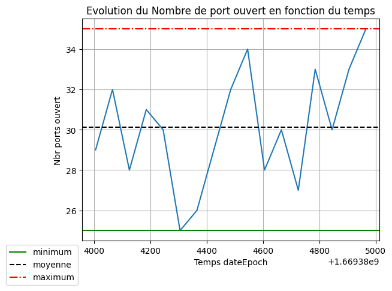

```python
"""graph"""

for i in range (0,len(listeTransposerMetrique1[0])):
    listeTransposerMetrique1[0][i] = float(listeTransposerMetrique1[0][i])
    listeTransposerMetrique1[1][i] = float(listeTransposerMetrique1[1][i])
affichageGraphique1(listeTransposerMetrique1[0], listeTransposerMetrique1[1])
```

Avec ce programme on obtient un historigramme sur le nombre de ports ouvert à un instant T

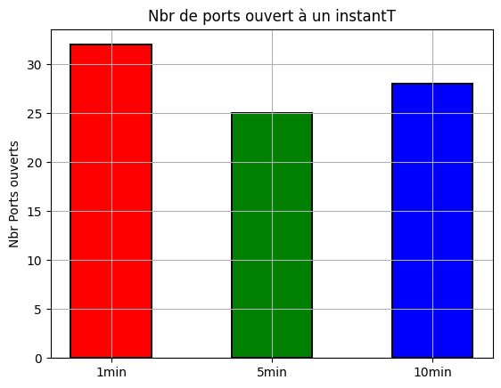

```python
"""bar"""
dicoBar = {'Ports ouverts' : listeTransposerMetrique1[1]}

port_ouvert_1min : List[int] = [listeTransposerMetrique1[1][1],listeTransposerMetrique1[1][5],listeTransposerMetrique1[1][10]]

affichageBar1(port_ouvert_1min)
```

### Metrique 3

Le programme ci-dessous permet l'affichage d'un graphique présentant l'évolution du temps de ping en fonction du temps, par ajout d'activités sur le réseaux.

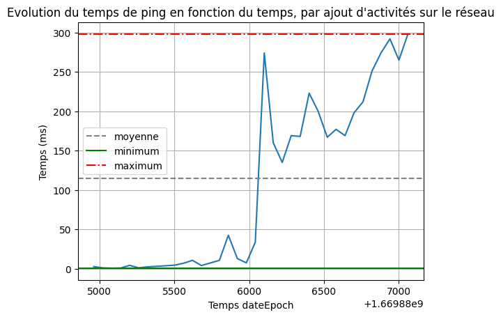

```python
# graphique

for i in range (0,len(listeExploitableMetrique3[0])):
    listeExploitableMetrique3[0][i] = float(listeExploitableMetrique3[0][i])
    listeExploitableMetrique3[7][i] = float(listeExploitableMetrique3[7][i])

affichageGraphique(listeExploitableMetrique3[0], listeExploitableMetrique3[7])
```

Le programme ci-dessous permet l'affichage d'un historigramme présentant l'évolution du débit moyen de différents types de fichiers de même taille.

[figure not shown]

```python
# bar

dicoBar : Dict = {'debitPdf' : listeExploitableMetrique3[4], 'debitPng' : listeExploitableMetrique3[5], 'debitJpg' : listeExploitableMetrique3[6]}

debitMoyAxey : List[float] = []

for cle in dicoBar.keys():
    debitMoyAxey.append(valeurMoy(dicoBar[cle] * 8))

affichageBar(debitMoyAxey)
```

Le programme ci-dessous permet l'affichage d'un camembert présentant le pourcentages de débit de téléchargements d'un fichiers Html supérieur ou inférieur à 15Mbps.

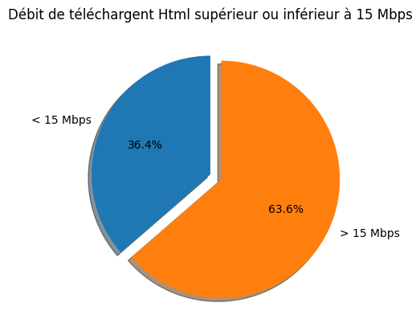

```python
# pie

listeInf : List[float] = []
listeSup : List[float] = []

for i in range(0, len(listeExploitableMetrique3[3])):
    if float(listeExploitableMetrique3[3][i]) * 8 < 15:
        listeInf.append(listeExploitableMetrique3[3][i])
    else :
        listeSup.append(listeExploitableMetrique3[3][i])

pourcentageInf : float = (len(listeInf)*100)/len(listeExploitableMetrique3[3])
pourcentageSup : float = (len(listeSup)*100)/len(listeExploitableMetrique3[3])

affichagePie([pourcentageInf, pourcentageSup])
```

Réaliser par REVERDY Marine et THEBAULT Enzo étudiant en R&T